# Bodyfat Dataset Revisited

Bruce Hartman

University of St. Francis

2026-08-14 Revised 2026-10-11T13:13:13

Abstract

We present an expanded bodyfat dataset linear model from Garcia et al. (2005) and interpret it with variable importance plots from `vip` and a surrogate model from `pre`.

# Introduction

The `bodyfat` dataset is famous in analytics. Its basic use is to show multicollinearity. This version has more variables.

# Packages

```r
library(ISLR2)
library(TH.data) # for bodyfat data
library(mbadtools, quietly=TRUE)
```

# Data

Garcia et al. (2005) report on the development of predictive regression equations for body fat content by means of common anthropometric measurements which were obtained for 71 healthy German women. In addition, the women’s body composition was measured by Dual Energy X-Ray Absorptiometry (DXA). This reference method is very accurate in measuring body fat but finds little applicability in practical environments, mainly because of high costs and the methodological efforts needed. Therefore, a simple regression equation for predicting DXA measurements of body fat is of special interest for the practitioner.

```r
data(bodyfat, package="TH.data")
??bodyfat
bodyfat %>% skim
```

```
── Data Summary ────────────────────────
                           Values
Name                       Piped data
Number of rows             71
Number of columns          10
_______________________
Column type frequency:
  numeric                  10
________________________
Group variables            None
```

|  | skim_variable | n_missing | complete_rate | mean | sd | p0 | p25 | p50 | p75 | p100 | hist |
| --- | --- | --- | --- | --- | --- | --- | --- | --- | --- | --- | --- |
| 1 | age | 0 | 1 | 50.859155 | 13.3751323 | 19.00 | 42.000 | 56.00 | 62.000 | 67.00 | ▂▂▂▃▇ |
| 2 | DEXfat | 0 | 1 | 30.782817 | 11.0427635 | 11.21 | 22.325 | 29.63 | 39.330 | 62.02 | ▆▇▆▃▁ |
| 3 | waistcirc | 0 | 1 | 87.383099 | 14.0283894 | 65.00 | 78.500 | 85.00 | 99.750 | 117.00 | ▆▇▅▆▂ |
| 4 | hipcirc | 0 | 1 | 105.280282 | 11.0404920 | 88.00 | 96.750 | 103.00 | 111.150 | 132.00 | ▆▇▆▃▂ |
| 5 | elbowbreadth | 0 | 1 | 6.508451 | 0.4563039 | 5.20 | 6.200 | 6.50 | 6.900 | 7.40 | ▁▂▇▅▃ |
| 6 | kneebreadth | 0 | 1 | 9.301408 | 0.9136259 | 7.20 | 8.600 | 9.20 | 9.800 | 11.80 | ▁▇▆▃▁ |
| 7 | anthro3a | 0 | 1 | 3.869155 | 0.4730622 | 2.40 | 3.540 | 3.97 | 4.155 | 4.68 | ▁▂▅▇▅ |
| 8 | anthro3b | 0 | 1 | 4.290845 | 0.4856240 | 2.58 | 4.060 | 4.39 | 4.660 | 5.01 | ▁▁▃▇▆ |
| 9 | anthro3c | 0 | 1 | 3.885634 | 0.5647066 | 2.05 | 3.480 | 3.99 | 4.345 | 4.62 | ▁▁▅▅▇ |
| 10 | anthro4 | 0 | 1 | 5.398028 | 0.6373710 | 3.18 | 5.040 | 5.53 | 5.840 | 6.37 | ▁▁▅▇▆ |

# Description

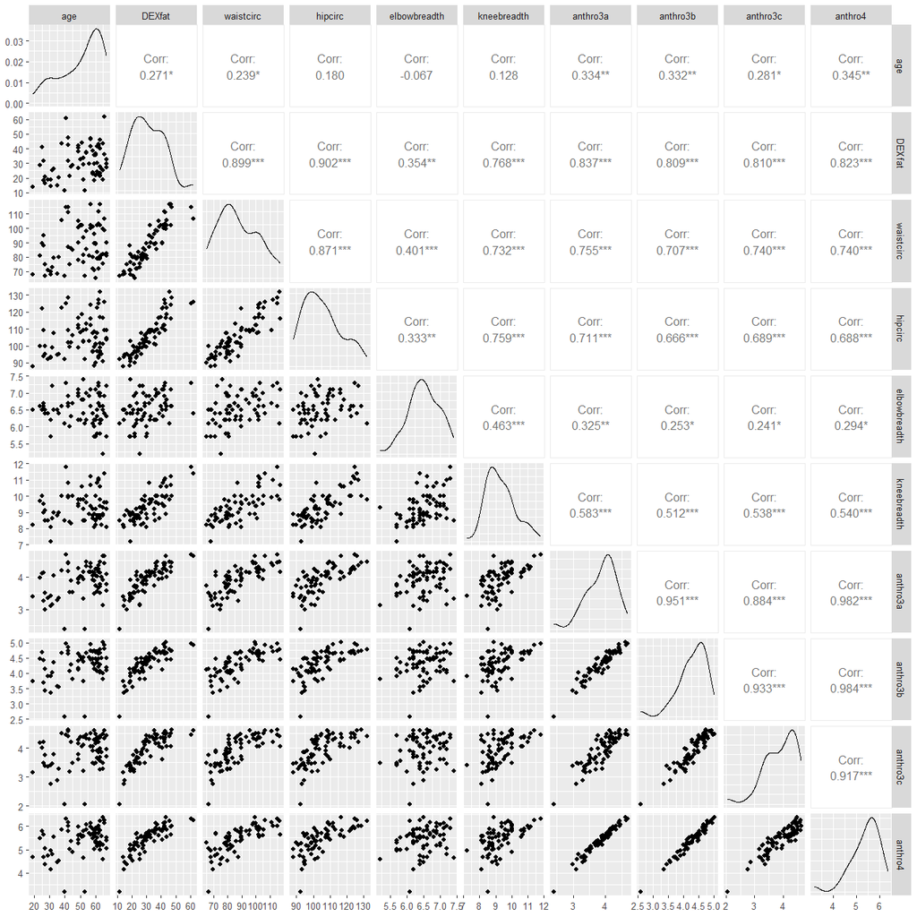

```r
bodyfat %>% ggpairs(progress=F)
```

Backward-elimination was applied in the study to select important variables from the available anthropometrical measurements, and Garcia (2005) report a final linear model utilizing hip circumference, knee breadth and a compound covariate which is defined as the sum of log chin skinfold, log triceps skinfold and log subscapular skinfold.

# Collinearity

Investigate collinearity. First the full model.

```r
fit = lm(DEXfat ~ ., data=bodyfat)
fit %>% glance() %>% gt_add_significance()
```

| r.squared | adj.r.squared | sigma | statistic | p.value | df | logLik | AIC | BIC | deviance | df.residual | nobs |
| --- | --- | --- | --- | --- | --- | --- | --- | --- | --- | --- | --- |
| 0.9231 | 0.9117 | 3.2806 | 81.3462 | 0.0000 | 9.0000 | −179.7063 | 381.4125 | 406.3020 | 656.5185 | 61.0000 | 71.0000 |

```r
fit %>% tidy(conf.int=TRUE) %>% gt_add_significance()
```

| term | estimate | std.error | statistic | p.value | conf.low | conf.high |
| --- | --- | --- | --- | --- | --- | --- |
| (Intercept) | −69.0283 | 7.5169 | −9.1831 | 0.0000 | −84.0592 | −53.9974 |
| age | 0.0200 | 0.0322 | 0.6197 | 0.5378 | −0.0445 | 0.0844 |
| waistcirc | 0.2105 | 0.0671 | 3.1348 | 0.0026 | 0.0762 | 0.3448 |
| hipcirc | 0.3435 | 0.0804 | 4.2740 | 0.0001 | 0.1828 | 0.5042 |
| elbowbreadth | −0.4124 | 1.0229 | −0.4031 | 0.6883 | −2.4578 | 1.6331 |
| kneebreadth | 1.7580 | 0.7250 | 2.4250 | 0.0183 | 0.3084 | 3.2076 |
| anthro3a | 5.7423 | 5.2075 | 1.1027 | 0.2745 | −4.6708 | 16.1554 |
| anthro3b | 9.8664 | 5.6579 | 1.7438 | 0.0862 | −1.4472 | 21.1800 |
| anthro3c | 0.3874 | 2.0875 | 0.1856 | 0.8534 | −3.7867 | 4.5616 |
| anthro4 | −6.5744 | 6.4892 | −1.0131 | 0.3150 | −19.5503 | 6.4015 |

The R-squared of the full model is:

```r
fit %>% glance %>% pull(r.squared)
```

```
[1] 0.9230881
```

Check collinearity with variance inflation factor, from package `car`:

```r
 car::vif(fit)
```

```
         age    waistcirc      hipcirc elbowbreadth  kneebreadth
    1.207378     5.770604     5.121272     1.416972     2.853228
    anthro3a     anthro3b     anthro3c      anthro4
   39.471164    49.100539     9.037833   111.261438
```

A VIF over 10 is an indication of multicollinearity of that variable.

```r
car::vif(fit)[car::vif(fit)>9]
```

```
  anthro3a   anthro3b   anthro3c    anthro4
 39.471164  49.100539   9.037833 111.261438
```

The `anthro...` are multicollinear because they are transforms of others.

Plot only the drivers; remember the overall r-squared is 0.9230881.

```r
cor(bodyfat %>% select(-DEXfat)) %>%
  data.frame %>% gt() %>% fmt_number() %>%
  gt::data_color( alpha = 0.2,
                  columns = everything(),
                  rows = everything(),
                  palette = c("blue","white","red"),
                  method="bin", bins=c(-.1, .3, .8, .999),
                  autocolor_text = FALSE)
```

| age | waistcirc | hipcirc | elbowbreadth | kneebreadth | anthro3a | anthro3b | anthro3c | anthro4 |
| --- | --- | --- | --- | --- | --- | --- | --- | --- |
| 1.00 | 0.24 | 0.18 | −0.07 | 0.13 | 0.33 | 0.33 | 0.28 | 0.34 |
| 0.24 | 1.00 | 0.87 | 0.40 | 0.73 | 0.76 | 0.71 | 0.74 | 0.74 |
| 0.18 | 0.87 | 1.00 | 0.33 | 0.76 | 0.71 | 0.67 | 0.69 | 0.69 |
| −0.07 | 0.40 | 0.33 | 1.00 | 0.46 | 0.33 | 0.25 | 0.24 | 0.29 |
| 0.13 | 0.73 | 0.76 | 0.46 | 1.00 | 0.58 | 0.51 | 0.54 | 0.54 |
| 0.33 | 0.76 | 0.71 | 0.33 | 0.58 | 1.00 | 0.95 | 0.88 | 0.98 |
| 0.33 | 0.71 | 0.67 | 0.25 | 0.51 | 0.95 | 1.00 | 0.93 | 0.98 |
| 0.28 | 0.74 | 0.69 | 0.24 | 0.54 | 0.88 | 0.93 | 1.00 | 0.92 |
| 0.34 | 0.74 | 0.69 | 0.29 | 0.54 | 0.98 | 0.98 | 0.92 | 1.00 |

# Klein’s Rule Method

This method runs auxiliary regressions on the potential drivers by omitting each variable in turn. If the r-squared of an aux regression is greater than the full model, we should omit that variable. Column `s` has a * if the condition for omission is met. There’s a function for it in `mbadtools`.

```r
Kleinsrule(bodyfat, target="DEXfat")
```

| formula | rsq | s |
| --- | --- | --- |
| DEXfat ~ . | 0.9230881 |  |
| age ~ . - age | 0.1717586 |  |
| waistcirc ~ . - waistcirc | 0.8267079 |  |
| hipcirc ~ . - hipcirc | 0.8047360 |  |
| elbowbreadth ~ . - elbowbreadth | 0.2942697 |  |
| kneebreadth ~ . - kneebreadth | 0.6495198 |  |
| anthro3a ~ . - anthro3a | 0.9746650 | * |
| anthro3b ~ . - anthro3b | 0.9796336 | * |
| anthro3c ~ . - anthro3c | 0.8893540 |  |
| anthro4 ~ . - anthro4 | 0.9910122 | * |

# Model

This is the model of Garcia et al. (2005).

```r
fmod <- lm(DEXfat ~ hipcirc + anthro3a + kneebreadth, data = bodyfat)
fmod %>% glance %>% gt_add_significance()
```

| r.squared | adj.r.squared | sigma | statistic | p.value | df | logLik | AIC | BIC | deviance | df.residual | nobs |
| --- | --- | --- | --- | --- | --- | --- | --- | --- | --- | --- | --- |
| 0.9017 | 0.8973 | 3.5382 | 204.9535 | 0.0000 | 3.0000 | −188.4024 | 386.8048 | 398.1182 | 838.7505 | 67.0000 | 71.0000 |

```r
fmod %>% tidy(conf.int=TRUE) %>% gt_add_significance()
```

| term | estimate | std.error | statistic | p.value | conf.low | conf.high |
| --- | --- | --- | --- | --- | --- | --- |
| (Intercept) | −75.2348 | 4.5313 | −16.6034 | 0.0000 | −84.2793 | −66.1903 |
| hipcirc | 0.5115 | 0.0683 | 7.4946 | 0.0000 | 0.3753 | 0.6478 |
| anthro3a | 8.9096 | 1.2770 | 6.9773 | 0.0000 | 6.3608 | 11.4584 |
| kneebreadth | 1.9020 | 0.7140 | 2.6638 | 0.0097 | 0.4768 | 3.3272 |

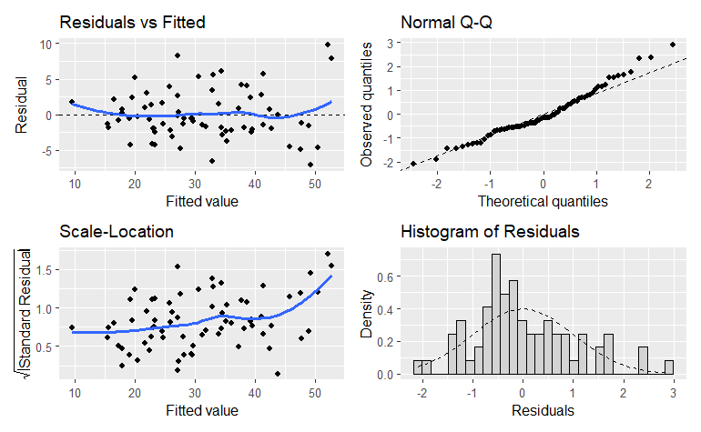

```r
fmod %>% gg_residual_plots()
```

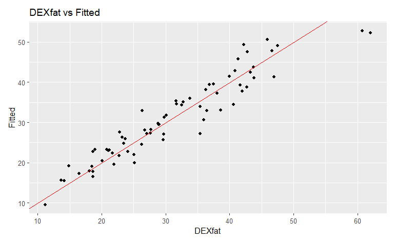

```r
fmod %>% gg_residual_plots(items=8) #YVP plot
```

```r
Kleinsrule(bodyfat %>% select(DEXfat, hipcirc, anthro3a, kneebreadth),
            "DEXfat")
```

| formula | rsq | s |
| --- | --- | --- |
| DEXfat ~ . | 0.9017394 |  |
| hipcirc ~ . - hipcirc | 0.6850450 |  |
| anthro3a ~ . - anthro3a | 0.5099133 |  |
| kneebreadth ~ . - kneebreadth | 0.5797534 |  |

Less evidence of multicollinearity.

# Interpretability

We check out interpretability with a variable importance plot and a RuleFit style decision tree.

# Variable Importance

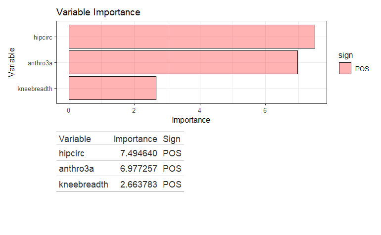

```r
V = vi(fmod)
V %>% gg_vip() / wrap_table(V %>% gt())
```

`hipcirc` and `anthro3a` are more important than `kneebreadth`.

## Partial Dependence

Partial dependence for linear models is not very interesting. It will always be linear for a linear model.

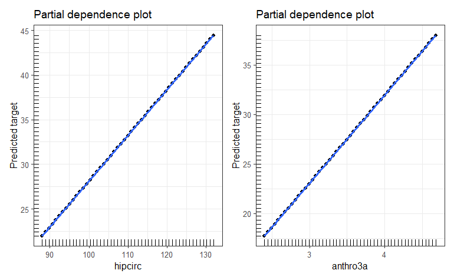

```r
HC=pdp::partial(fmod, "hipcirc") %>% gg_pdp()
AN=pdp::partial(fmod, "anthro3a") %>% gg_pdp()
HC+AN
```

## Surrogate with RuleFit

We make a surrogate tree model with RuleFit and the `pre` package; need to specify package `pre` for importance calculations.

```r
pre_model <- pre(DEXfat ~ hipcirc + anthro3a + kneebreadth,
                 data = bodyfat,
                 family = "gaussian", ntrees = 100)
pre::importance(pre_model, plot=F)$baseimps# %>% head(6)
```

| rule | description | imp | coefficient | sd |
| --- | --- | --- | --- | --- |
| hipcirc | 89.575 <= hipcirc <= 127.375 | 3.7584775 | 0.3480672 | 10.7981361 |
| anthro3a | 2.8425 <= anthro3a <= 4.6325 | 3.1462958 | 7.2017703 | 0.4368781 |
| rule30 | hipcirc > 99 & hipcirc > 109.5 | 0.8240727 | 1.8482692 | 0.4458618 |
| rule13 | hipcirc <= 108 & hipcirc <= 100 | 0.6726766 | -1.3666939 | 0.4921926 |
| kneebreadth | 8.1 <= kneebreadth <= 11.25 | 0.4919157 | 0.5685369 | 0.8652310 |
| rule163 | anthro3a > 3.48 & hipcirc > 99 | 0.4145571 | 0.8544164 | 0.4851932 |
| rule10 | hipcirc <= 108 | 0.2276830 | -0.4692624 | 0.4851932 |
| rule26 | hipcirc <= 103.6 | 0.1137826 | -0.2265193 | 0.5023086 |

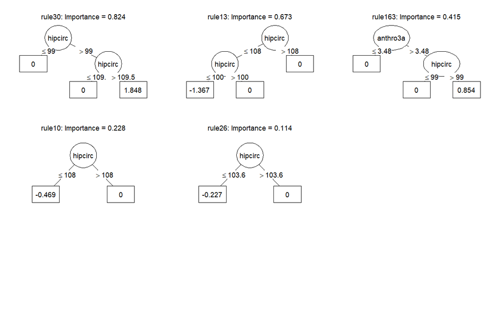

```r
plot(pre_model, linear.terms = FALSE, nterms=6)
```

```r
print(pre_model) %>% slice(2:7)
```

```
Final ensemble with cv error within 1se of minimum:

  lambda =  0.6987726
  number of terms = 8
  mean cv error (se) = 19.27392 (4.749176)

  cv error type : Mean-Squared Error

         rule  coefficient                      description
  (Intercept)  -39.1648394                                1
     anthro3a    7.2017703     2.8425 <= anthro3a <= 4.6325
       rule30    1.8482692   hipcirc > 99 & hipcirc > 109.5
       rule13   -1.3666939  hipcirc <= 108 & hipcirc <= 100
      rule163    0.8544164   anthro3a > 3.48 & hipcirc > 99
  kneebreadth    0.5685369      8.1 <= kneebreadth <= 11.25
       rule10   -0.4692624                   hipcirc <= 108
      hipcirc    0.3480672     89.575 <= hipcirc <= 127.375
       rule26   -0.2265193                 hipcirc <= 103.6
```

| rule | coefficient | description |
| --- | --- | --- |
| anthro3a | 7.2017703 | 2.8425 <= anthro3a <= 4.6325 |
| rule30 | 1.8482692 | hipcirc > 99 & hipcirc > 109.5 |
| rule13 | -1.3666939 | hipcirc <= 108 & hipcirc <= 100 |
| rule163 | 0.8544164 | anthro3a > 3.48 & hipcirc > 99 |
| kneebreadth | 0.5685369 | 8.1 <= kneebreadth <= 11.25 |
| rule10 | -0.4692624 | hipcirc <= 108 |

## Display

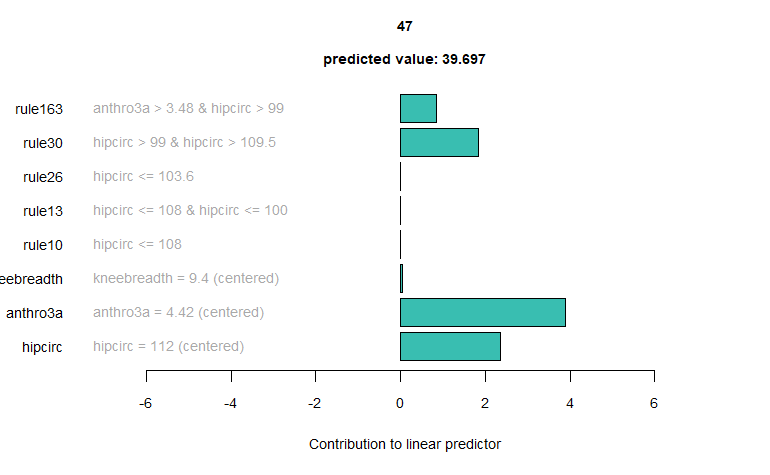

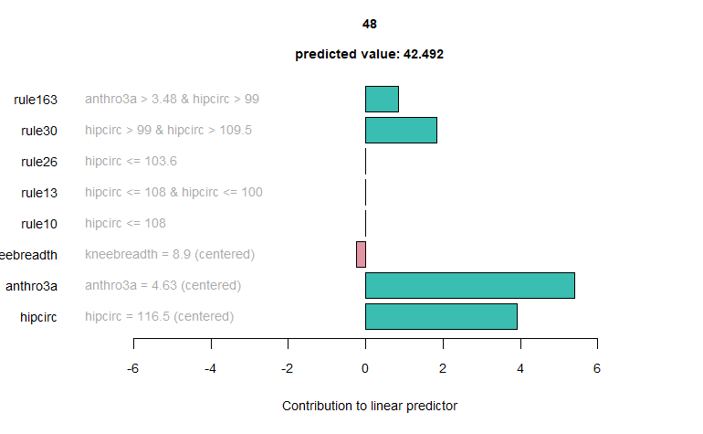

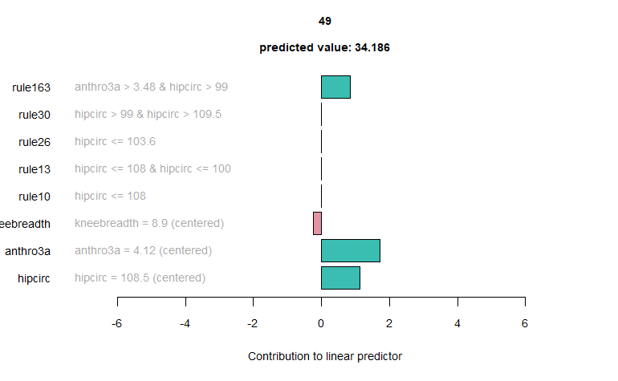

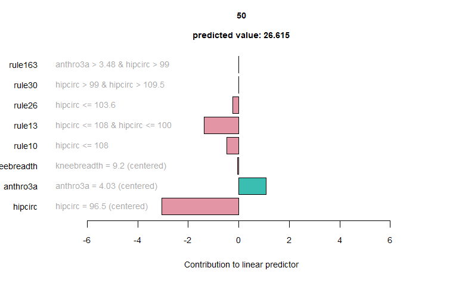

```r
# averages of entire dataset
pre.ens.exp <- pre::explain(pre_model, newdata = bodyfat,
                            center.linear = TRUE)
```

```r
pre.ens.exp$contribution %>% data.frame() %>% gt() %>%
  fmt_number() %>% opt_interactive()
```

| hipcirc | anthro3a | kneebreadth | rule10 | rule13 | rule26 | rule30 | rule163 |
| --- | --- | --- | --- | --- | --- | --- | --- |
| 2.35313069986073 | 3.88286994539798 | 0.0544514174385158 | 0 | 0 | 0 | 1.84826918849037 | 0.854416432479746 |
| 3.91943332195553 | 5.39524170312745 | -0.229817011836088 | 0 | 0 | 0 | 1.84826918849037 | 0.854416432479746 |
| 1.13489532712033 | 1.72233886292732 | -0.229817011836088 | 0 | 0 | 0 | 0 | 0.854416432479746 |
| -3.04191166513247 | 1.07417953818612 | -0.0592559542713266 | -0.469262445349574 | -1.36669389826329 | -0.226519268359808 | 0 | 0 |
| -1.64964266771487 | 2.58655129591559 | 0.395573532568039 | -0.469262445349574 | 0 | -0.226519268359808 | 0 | 0.854416432479746 |
| -2.86787804045526 | -2.38267019376695 | -0.286670697691008 | -0.469262445349574 | -1.36669389826329 | -0.226519268359808 | 0 | 0 |
| -0.779474544328865 | 1.86637426842536 | -0.229817011836088 | -0.469262445349574 | 0 | -0.226519268359808 | 0 | 0.854416432479746 |
| -0.0833400456200661 | 1.14619724093514 | -0.45723175525577 | -0.469262445349574 | 0 | 0 | 0 | 0.854416432479746 |
| -2.86787804045526 | 0.209967105197854 | -0.286670697691008 | -0.469262445349574 | -1.36669389826329 | -0.226519268359808 | 0 | 0 |
| -4.26014703787286 | -1.5904754635277 | -0.286670697691008 | -0.469262445349574 | -1.36669389826329 | -0.226519268359808 | 0 | 0 |

[output cut: 61 more lines]

## Compare Models

```r
lm_predictions <- predict(fmod, newdata = bodyfat)
pre_predictions <- predict(pre_model, newdata = bodyfat)
```

A good interpretation method or surrogate model should not sacrifice too much predictive accuracy. We choose R-squared. We evaluate on all the data.

```r
lm_rsq <- yardstick::rsq_vec(bodyfat$DEXfat, lm_predictions)
pre_rsq <- yardstick::rsq_vec(bodyfat$DEXfat, pre_predictions)

cat("Linear Model Rsquared:", lm_rsq, "\n")
```

```
Linear Model Rsquared: 0.9017394
```

```r
cat("Rule-based (pre) Rsquared:", pre_rsq, "\n")
```

```
Rule-based (pre) Rsquared: 0.904772
```

## Alternate YVP comparison

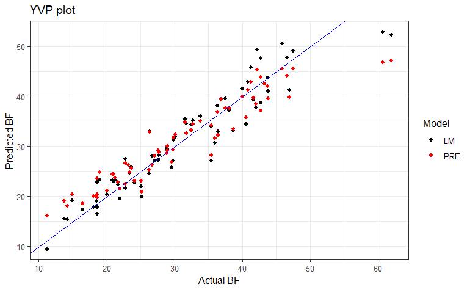

```r
d = data.frame(BF=bodyfat$DEXfat, LM=lm_predictions, PRE=pre_predictions)
ggplot(d) +
  geom_point(aes(BF,LM, color="LM")) +
  geom_point(aes(BF,PRE, color="PRE")) +
  geom_abline(aes(slope=1, intercept=0), color="blue") +
  scale_color_manual(name = "Model",
                     values = c("LM" = "black", "PRE" = "red")) +
  labs(title="YVP plot", x="Actual BF", y="Predicted BF") +
  theme_bw()
```

Both predictions do a pretty good job; the PRE model is more wrong at the ends.

Another way to do it:

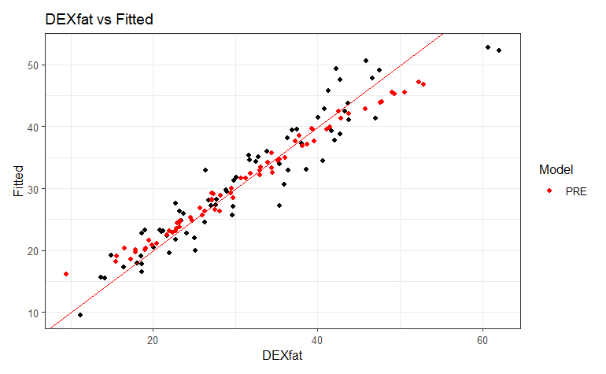

```r
fmod %>% gg_residual_plots(items=8) +
  geom_point(aes(fmod$fitted.values, pre_predictions, color="PRE")) +
  scale_color_manual(name = "Model",
                     values = c("LM" = "black", "PRE" = "red")) +
  theme_bw()
```

# Conclusions

We analyzed the Garcia linear model of `DEXfat` in the `bodyfat` dataset, and obtained 90% R-squared.

We also tried a surrogate explainable model with RuleFit using `pre` and found a (perhaps) more explainable model that captured 90% of the predictive variation in the linear model.

How useful is this for medical personnel? Read the reference for their take.

# References

Ada L. Garcia, Karen Wagner, Torsten Hothorn, Corinna Koebnick, Hans-Joachim F. Zunft and Ulrike Trippo (2005), Improved prediction of body fat by measuring skinfold thickness, circumferences, and bone breadths. Obesity Research, 13(3), 626–634